# Project: Identify Customer Segments

```
Underrepresented Customer data
```

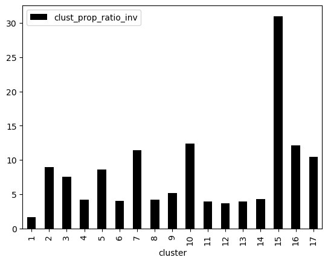

```python
# cluster prop ratio inverted
print('Underrepresented Customer data')
cluster_data.plot(x='cluster',y='clust_prop_ratio_inv',kind='bar',color='k')
```

> **Cluster 15 is underrepresented in the customer dataset**

```python
# What kinds of people are part of a cluster that is underrepresented in the
# customer data compared to the general population?
clust_15 = pd.Series(kmeans_17.cluster_centers_[14],index=np.arange(len(kmeans_17.cluster_centers_[14]))+1)
clust_15.sort_values(ascending=False, inplace=True)

clust_15[:3]
```

```
15    9.732090
19    0.444072
14    0.350586
dtype: float64
```

```
Most influencial PCA components of this Underrepresented cluster are...
Component 15 explains 1.56% of the variance
```

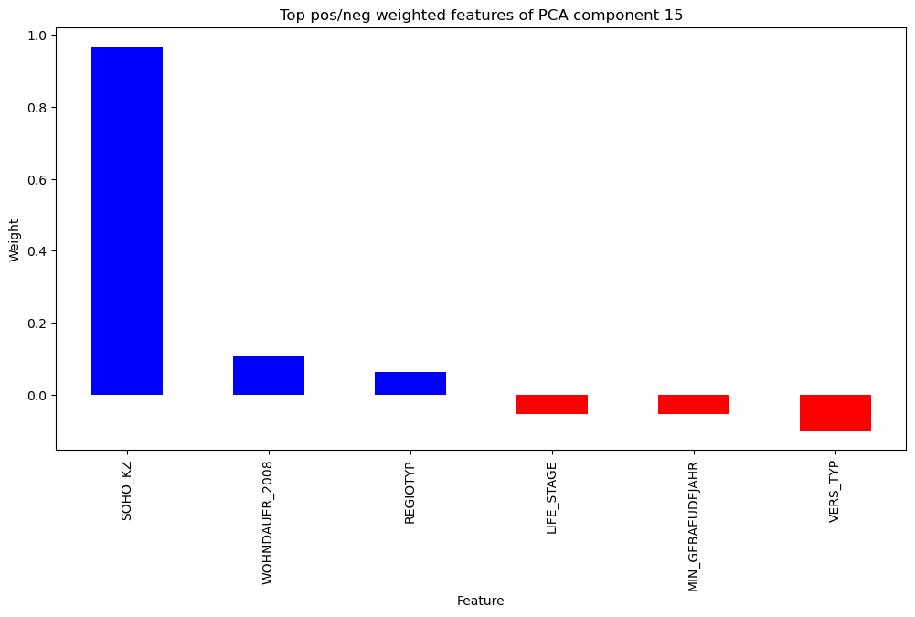

```
Component 19 explains 1.39% of the variance
```

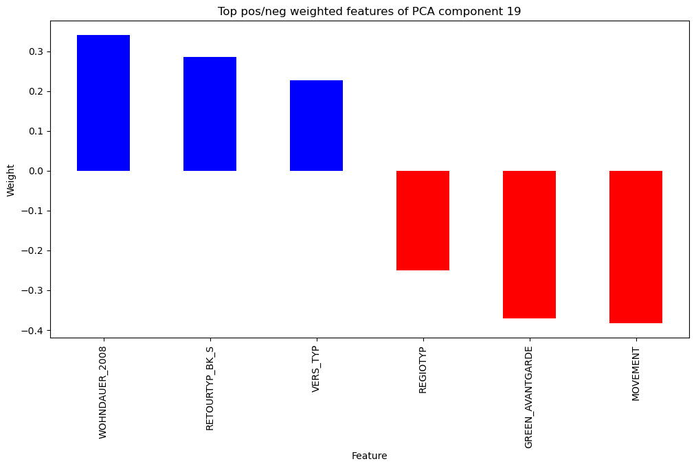

```
Component 14 explains 1.65% of the variance
```

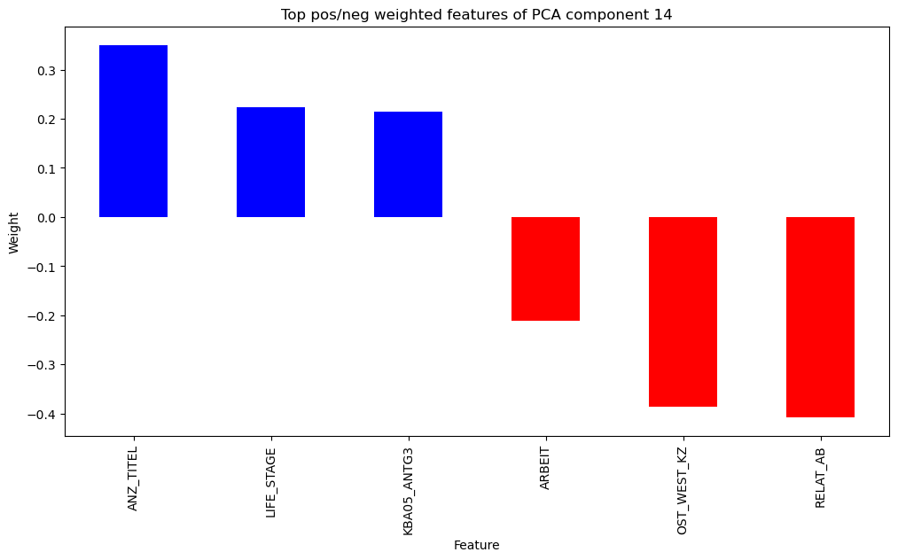

```python
print('Most influencial PCA components of this Underrepresented cluster are...')
for n in clust_15[:3].index:
    map_weights(customers_data_scaled,pca_customer,n-1)#subtract one added to index
```

### Discussion 3.3: Compare Customer Data to Demographics Data

> From the cluster analysis dividing the dataset into 17 clusters, the customer base is overrepresented by cluster 1. From the PCA, cluster 1 seems to represent persons involved avantgarde or environmental sustainability during their youth, who also live in buildings with a high number of 10+ families. Whereas the their customer base is underrepresented by cluster 15, which seems primarily represent persons with a small home office, perhaps academics.

> Congratulations on making it this far in the project! Before you finish, make sure to check through the entire notebook from top to bottom to make sure that your analysis follows a logical flow and all of your findings are documented in **Discussion** cells. Once you've checked over all of your work, you should export the notebook as an HTML document to submit for evaluation. You can do this from the menu, navigating to **File -> Download as -> HTML (.html)**. You will submit both that document and this notebook for your project submission.